# FOR/STT 875, Exercise 3

## Learning objectives

- create, subset, and manipulate vector contents and attributes
- summarize vector data using R `tables` and other functions
- generate frequency and timeseries graphics using vector data

## Overview and deliverables

Modify this R Markdown file by filling in the code needed to answer the questions. The Exercise 3 video provides some guidance for completing this exercise.

## Submission instructions

Upload your exercise_3.rmd and exercise_3.html files to the Exercise 3 D2L dropbox.

## Grading

You will receive full credit if your R Markdown document: 1) compiles without error; 2) correctly answers the questions below; and 3) is neatly formatted.

## Getting started

First we’ll set code chunk options to be applied to the entire document, unless overridden by the options in an individual code chunk. Typically we would use `echo = FALSE` in this chunk, since we wouldn’t want it seen in the final document, but here we display the chunk.

```r
knitr::opts_chunk$set(comment = NA, tidy = TRUE)
```

## The data

http://www.denverpost.com/2017/05/01/oil-gas-wells-colorado-map/

As noted in the learning objectives, this exercise provides some practice with vectors. We’ll read in three vectors, one that lists the teams who won the World Series, one that lists the teams who lost the World Series, and a third that gives the years the World Series was played.

```r
con <- url("http://blue.for.msu.edu/STT301/data/WorldSeries.gz")
load(con)
close(con)
rm(con)
ls()
```

```
[1] "losers"  "winners" "years"
```

List the first 50 World Series winning teams.

```r
winners[1:50]
```

```
 [1] "Boston Americans"       "New York Giants"
 [3] "Chicago White Sox"      "Chicago Cubs"
 [5] "Chicago Cubs"           "Pittsburg Pirates"
 [7] "Philadelphia Athletics" "Philadelphia Athletics"
 [9] "Boston Red Sox"         "Philadelphia Athletics"
[11] "Boston Braves"          "Boston Red Sox"
[13] "Boston Red Sox"         "Chicago White Sox"
[15] "Boston Red Sox"         "Cincinnati Reds"
[17] "Cleveland Indians"      "New York Giants"
[19] "New York Giants"        "New York Yankees"
[21] "Washington Senators"    "Pittsburgh Pirates"
[23] "St. Louis Cardinals"    "New York Yankees"
[25] "New York Yankees"       "Philadelphia Athletics"
[27] "Philadelphia Athletics" "St. Louis Cardinals"
[29] "New York Yankees"       "New York Giants"
[31] "St. Louis Cardinals"    "Detroit Tigers"
[33] "New York Yankees"       "New York Yankees"
[35] "New York Yankees"       "New York Yankees"
[37] "Cincinnati Reds"        "New York Yankees"
[39] "St. Louis Cardinals"    "New York Yankees"
[41] "St. Louis Cardinals"    "Detroit Tigers"
[43] "St. Louis Cardinals"    "New York Yankees"
[45] "Cleveland Indians"      "New York Yankees"
[47] "New York Yankees"       "New York Yankees"
[49] "New York Yankees"       "New York Yankees"
```

List the first 50 World Series losing teams.

```r
losers[1:50]
```

```
 [1] "Pittsburg Pirates"      "Philadelphia Athletics"
 [3] "Chicago Cubs"           "Detroit Tigers"
 [5] "Detroit Tigers"         "Detroit Tigers"
 [7] "Chicago Cubs"           "New York Giants"
 [9] "New York Giants"        "New York Giants"
[11] "Philadelphia Athletics" "Philadelphia Phillies"
[13] "Brooklyn Robins"        "New York Giants"
[15] "Chicago Cubs"           "Chicago White Sox"
[17] "Brooklyn Robins"        "New York Yankees"
[19] "New York Yankees"       "New York Giants"
[21] "New York Giants"        "Washington Senators"
[23] "New York Yankees"       "Pittsburgh Pirates"
[25] "St. Louis Cardinals"    "Chicago Cubs"
[27] "St. Louis Cardinals"    "Philadelphia Athletics"
[29] "Chicago Cubs"           "Washington Senators"
[31] "Detroit Tigers"         "Chicago Cubs"
[33] "New York Giants"        "New York Giants"
[35] "Chicago Cubs"           "Cincinnati Reds"
[37] "Detroit Tigers"         "Brooklyn Dodgers"
[39] "New York Yankees"       "St. Louis Cardinals"
[41] "St. Louis Browns"       "Chicago Cubs"
[43] "Boston Red Sox"         "Brooklyn Dodgers"
[45] "Boston Braves"          "Brooklyn Dodgers"
[47] "Philadelphia Phillies"  "New York Giants"
[49] "Brooklyn Dodgers"       "Brooklyn Dodgers"
```

List the first 50 years that the World Series was played.

```r
years[1:50]
```

```
 [1] 1903 1905 1906 1907 1908 1909 1910 1911 1912 1913 1914 1915 1916 1917
[15] 1918 1919 1920 1921 1922 1923 1924 1925 1926 1927 1928 1929 1930 1931
[29] 1932 1933 1934 1935 1936 1937 1938 1939 1940 1941 1942 1943 1944 1945
[43] 1946 1947 1948 1949 1950 1951 1952 1953
```

The `table` function builds a contingency table. For example,

```r
animals <- c("dog", "cat", "dog", "cat", "horse", "dog")
table(animals)
```

```
animals
  cat   dog horse
    2     3     1
```

Create a table which gives the number of times each team has won the World Series.

```r
table(winners)
```

```
winners
        Anaheim Angels   Arizona Diamondbacks         Atlanta Braves
                     1                      1                      1
     Baltimore Orioles       Boston Americans          Boston Braves
                     3                      1                      1
        Boston Red Sox       Brooklyn Dodgers           Chicago Cubs
                     7                      1                      2
     Chicago White Sox        Cincinnati Reds      Cleveland Indians
                     3                      5                      2
        Detroit Tigers        Florida Marlins     Kansas City Royals
                     4                      2                      1
   Los Angeles Dodgers       Milwaukee Braves        Minnesota Twins
                     5                      1                      2
       New York Giants          New York Mets       New York Yankees
                     5                      2                     27
     Oakland Athletics Philadelphia Athletics  Philadelphia Phillies
                     4                      5                      2
    Pittsburgh Pirates      Pittsburg Pirates   San Francisco Giants
                     4                      1                      3
   St. Louis Cardinals      Toronto Blue Jays    Washington Senators
                    11                      2                      1
```

By default the table is ordered alphabetically by the name of the team. It might be more useful to order by the number of World Series won. Apply the `sort` function to the table to achieve this, and save the resulting table as `winners_table`.

```r
winners_table <- sort(table(winners))
winners_table
```

```
winners
        Anaheim Angels   Arizona Diamondbacks         Atlanta Braves
                     1                      1                      1
      Boston Americans          Boston Braves       Brooklyn Dodgers
                     1                      1                      1
    Kansas City Royals       Milwaukee Braves      Pittsburg Pirates
                     1                      1                      1
   Washington Senators           Chicago Cubs      Cleveland Indians
                     1                      2                      2
       Florida Marlins        Minnesota Twins          New York Mets
                     2                      2                      2
 Philadelphia Phillies      Toronto Blue Jays      Baltimore Orioles
                     2                      2                      3
     Chicago White Sox   San Francisco Giants         Detroit Tigers
                     3                      3                      4
     Oakland Athletics     Pittsburgh Pirates        Cincinnati Reds
                     4                      4                      5
   Los Angeles Dodgers        New York Giants Philadelphia Athletics
                     5                      5                      5
        Boston Red Sox    St. Louis Cardinals       New York Yankees
                     7                     11                     27
```

Which two teams have won the most World Series?

Use the `[]` subsetting capabilities of R applied to `winners_table` to create a table called `top_winners` which contains the five teams which won the World Series most often. (There are several teams which are tied with five wins, and two of these will show up in the fourth and fifth positions. Don’t worry about the fact that we should include the other teams too.)

```r
top_winners <- winners_table[(length(winners_table) - 4):length(winners_table)]
top_winners
```

```
winners
       New York Giants Philadelphia Athletics         Boston Red Sox
                     5                      5                      7
   St. Louis Cardinals       New York Yankees
                    11                     27
```

Draw a bar graph of the `top_winners` table using the `barplot` function.

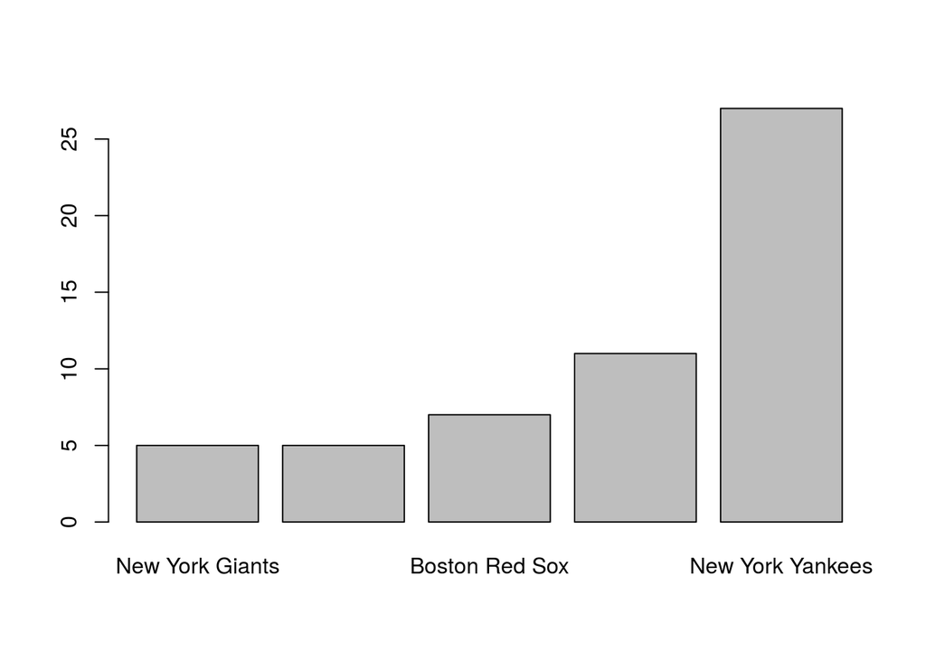

```r
barplot(top_winners)
```

It’s likely that the labels for some of the bars did not fit on the bar graph you drew. The argument `cex.names` allows you to increase (with values larger than 1) or decrease (with values less than 1) the size of the font. Experiment with `cex.names` to get the labels all to fit on the graph.

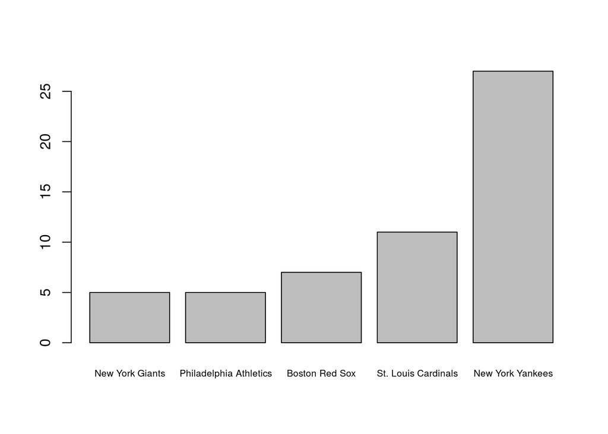

```r
barplot(top_winners, cex.names = 0.65)
```

Now create a table of the losing teams, and sort in decreasing order, by giving the `decreasing = TRUE` argument to `sort`.

```r
losing_table <- sort(table(losers), decreasing = TRUE)
losing_table
```

```
losers
      New York Yankees        New York Giants           Chicago Cubs
                    13                      9                      8
   St. Louis Cardinals         Detroit Tigers       Brooklyn Dodgers
                     8                      7                      6
 Philadelphia Phillies         Atlanta Braves         Boston Red Sox
                     5                      4                      4
       Cincinnati Reds    Los Angeles Dodgers      Baltimore Orioles
                     4                      4                      3
     Cleveland Indians Philadelphia Athletics   San Francisco Giants
                     3                      3                      3
       Brooklyn Robins      Chicago White Sox     Kansas City Royals
                     2                      2                      2
         New York Mets      Oakland Athletics       San Diego Padres
                     2                      2                      2
         Texas Rangers    Washington Senators          Boston Braves
                     2                      2                      1
      Colorado Rockies         Houston Astros       Milwaukee Braves
                     1                      1                      1
     Milwaukee Brewers        Minnesota Twins     Pittsburgh Pirates
                     1                      1                      1
     Pittsburg Pirates       St. Louis Browns         Tampa Bay Rays
                     1                      1                      1
```

Which two teams have lost the World Series most often?

Create a bar graph of the five teams which have lost most often, again making sure the labels are all printed.

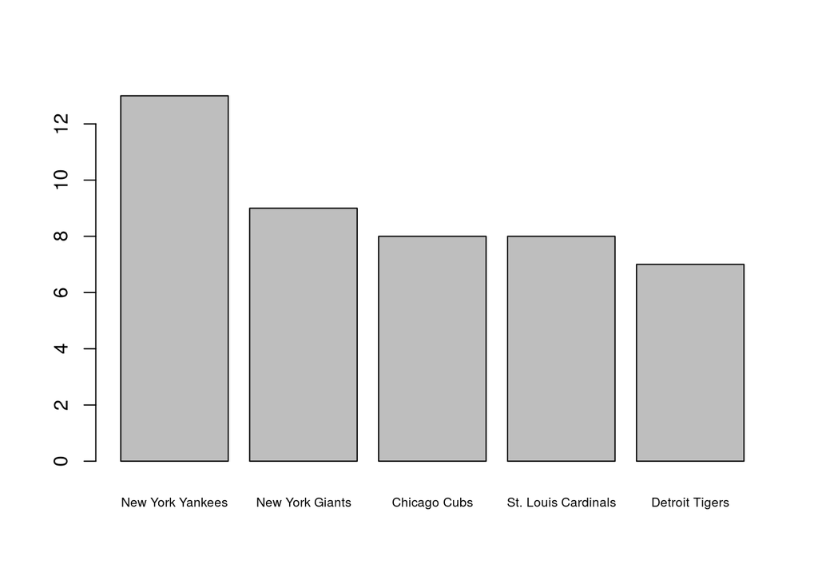

```r
barplot(losing_table[1:5], cex.names = 0.65)
```

Use R to find out how many years has the World Series been played.

```r
length(years)
```

```
[1] 110
```

Use R to list the most recent World Series winner. Do this in a way that does NOT require you to know how many World Series there have been.

```r
winners[length(winners)]
```

```
[1] "San Francisco Giants"
```

Use R to list the past eight World Series LOSING teams. Again, you shouldn’t need to know how many World Series have been played.

```r
losers[(length(losers) - 7):length(losers)]
```

```
[1] "Colorado Rockies"      "Tampa Bay Rays"        "Philadelphia Phillies"
[4] "Texas Rangers"         "Texas Rangers"         "Detroit Tigers"
[7] "St. Louis Cardinals"   "Kansas City Royals"
```

```r
losers[-(1:(length(losers) - 8))]
```

```
[1] "Colorado Rockies"      "Tampa Bay Rays"        "Philadelphia Phillies"
[4] "Texas Rangers"         "Texas Rangers"         "Detroit Tigers"
[7] "St. Louis Cardinals"   "Kansas City Royals"
```

The vectors listing the winning and losing teams would be more informative if the years of the wins and losses were included. We can give names to each vector element using the `names` function. For example:

```r
animals
```

```
[1] "dog"   "cat"   "dog"   "cat"   "horse" "dog"
```

```r
names(animals) <- c("Asta", "Felix", "Chopper", "Garfield", "Mr. Ed", "Lassie")
animals
```

```
    Asta    Felix  Chopper Garfield   Mr. Ed   Lassie
   "dog"    "cat"    "dog"    "cat"  "horse"    "dog"
```

Use `names` to add the years of the World Series as names for both the `winners` and `losers` vectors, and list the first ten elements of each vector with the names included.

```r
names(winners) <- years
names(losers) <- years
winners[1:10]
```

```
                    1903                     1905                     1906
      "Boston Americans"        "New York Giants"      "Chicago White Sox"
                    1907                     1908                     1909
          "Chicago Cubs"           "Chicago Cubs"      "Pittsburg Pirates"
                    1910                     1911                     1912
"Philadelphia Athletics" "Philadelphia Athletics"         "Boston Red Sox"
                    1913
"Philadelphia Athletics"
```

```r
losers[1:10]
```

```
                    1903                     1905                     1906
     "Pittsburg Pirates" "Philadelphia Athletics"           "Chicago Cubs"
                    1907                     1908                     1909
        "Detroit Tigers"         "Detroit Tigers"         "Detroit Tigers"
                    1910                     1911                     1912
          "Chicago Cubs"        "New York Giants"        "New York Giants"
                    1913
       "New York Giants"
```

Create a vector called `sorted_winners` which gives the winning teams sorted alphabetically. List the first thirty teams in this vector, and find (by inspection) the years when the Cleveland Indians won the World Series.

```r
sorted_winners <- sort(winners)
sorted_winners[1:30]
```

```
                  2002                   2001                   1995
      "Anaheim Angels" "Arizona Diamondbacks"       "Atlanta Braves"
                  1966                   1970                   1983
   "Baltimore Orioles"    "Baltimore Orioles"    "Baltimore Orioles"
                  1903                   1914                   1912
    "Boston Americans"        "Boston Braves"       "Boston Red Sox"
                  1915                   1916                   1918
      "Boston Red Sox"       "Boston Red Sox"       "Boston Red Sox"
                  2004                   2007                   2013
      "Boston Red Sox"       "Boston Red Sox"       "Boston Red Sox"
                  1955                   1907                   1908
    "Brooklyn Dodgers"         "Chicago Cubs"         "Chicago Cubs"
                  1906                   1917                   2005
   "Chicago White Sox"    "Chicago White Sox"    "Chicago White Sox"
                  1919                   1940                   1975
     "Cincinnati Reds"      "Cincinnati Reds"      "Cincinnati Reds"
                  1976                   1990                   1920
     "Cincinnati Reds"      "Cincinnati Reds"    "Cleveland Indians"
                  1948                   1935                   1945
   "Cleveland Indians"       "Detroit Tigers"       "Detroit Tigers"
```

### More advanced subsetting

So far we have directly specified the elements of vectors that we want to extract, for example `winners[1]` or `losers[length(losers)]` or `winners[c(1,2,3,5)]`. More typically we want to extract elements that meet a condition, such as all the winners before 1950, or all the losers during years when the New York Yankees won the World Series. For this we use subsetting with logical vectors. This is formally discussed in Section 4.7 of the notes, but we will informally use it now.

First some examples with very simple vectors, and then you’ll use these ideas for the World Series vectors.

```r
set.seed(123)  #Set the seed for reproducible random number generation
x <- rbinom(10, 20, 0.9)  #Generate 10 binomial(20, 0.9) values
y <- rbinom(10, 20, 0.8)  #Generate 10 binomial(20, 0.8) values
x
```

```
 [1] 19 17 18 16 16 20 18 16 18 18
```

```r
y
```

```
 [1] 13 16 15 16 18 14 17 19 17 13
```

```r
x[x > 16]  #Values of x which are larger than 16
```

```
[1] 19 17 18 20 18 18 18
```

```r
x[x == 18]  #Values of x which are equal to 18
```

```
[1] 18 18 18 18
```

```r
length(x[x == 18])  #How many values of x are equal to 18?
```

```
[1] 4
```

```r
x[y < 15]  #Values of x for which the corresponding values of y are less than 15
```

```
[1] 19 20 18
```

```r
x[x < y]  #Values of x which are less than the correponding values of y
```

```
[1] 16 16
```

```r
x[x == 18] <- 0  #Replace 18 by 0 in x
x
```

```
 [1] 19 17  0 16 16 20  0 16  0  0
```

Now we use logical subsetting to learn about the World Series data. First, use logical subsetting to count the number of World Series won by the Detroit Tigers, and also to count the number of World Series lost by the Detroit Tigers.

```r
length(winners[winners == "Detroit Tigers"])
```

```
[1] 4
```

```r
length(losers[losers == "Detroit Tigers"])
```

```
[1] 7
```

Next use logical subsetting to determine the years when the Baltimore Orioles won the World Series.

```r
years[winners == "Baltimore Orioles"]
```

```
[1] 1966 1970 1983
```

Next use logical subsetting to determine the losing teams during the years when the St. Louis Cardianals won the World Series.

```r
losers[winners == "St. Louis Cardinals"]
```

```
                    1926                     1931                     1934
      "New York Yankees" "Philadelphia Athletics"         "Detroit Tigers"
                    1942                     1944                     1946
      "New York Yankees"       "St. Louis Browns"         "Boston Red Sox"
                    1964                     1967                     1982
      "New York Yankees"         "Boston Red Sox"      "Milwaukee Brewers"
                    2006                     2011
        "Detroit Tigers"          "Texas Rangers"
```

We can combine conditions with the operators `&` and `|` which represent “and” and “or”. Also `!` negates, so for example `!=` represents not equal to. Also `x %in% y` is useful:

```r
letters
```

```
 [1] "a" "b" "c" "d" "e" "f" "g" "h" "i" "j" "k" "l" "m" "n" "o" "p" "q"
[18] "r" "s" "t" "u" "v" "w" "x" "y" "z"
```

```r
letters %in% c("a", "m", "q", "s")
```

```
 [1]  TRUE FALSE FALSE FALSE FALSE FALSE FALSE FALSE FALSE FALSE FALSE
[12] FALSE  TRUE FALSE FALSE FALSE  TRUE FALSE  TRUE FALSE FALSE FALSE
[23] FALSE FALSE FALSE FALSE
```

Use these ideas to

1. Extract the years when either the Boston Red Sox or the Chicago White Sox won the World Series.
2. Extract the years when the New York Yankees won the World Series and the New York Giants lost the World Series.
3. Extract the winners during the years 1903, 1923, 1943, 1963, 1983.
4. Count the number of years during which a team from Boston won the World Series. Be careful: There are three teams from Boston in the data set.

```r
# a
years[winners %in% c("Boston Red Sox", "Chicago White Sox")]
```

```
 [1] 1906 1912 1915 1916 1917 1918 2004 2005 2007 2013
```

```r
# b
years[winners == "New York Yankees" & losers == "New York Giants"]
```

```
[1] 1923 1936 1937 1951
```

```r
# c
winners[years %in% c(1903, 1923, 1943, 1963, 1983)]
```

```
                 1903                  1923                  1943
   "Boston Americans"    "New York Yankees"    "New York Yankees"
                 1963                  1983
"Los Angeles Dodgers"   "Baltimore Orioles"
```

```r
# d
length(winners[winners %in% c("Boston Red Sox", "Boston Americans", "Boston Braves")])
```

```
[1] 9
```

### Another data set

Data on the number, in thousands, of international airline passengers from 1949-1960 are built in to R. These are in the form of a time series, and we’ll first convert these to a vector since that’s the type of data structure we currently know how to work with.

```r
passengers <- as.vector(AirPassengers)
passengers
```

```
  [1] 112 118 132 129 121 135 148 148 136 119 104 118 115 126 141 135 125
 [18] 149 170 170 158 133 114 140 145 150 178 163 172 178 199 199 184 162
 [35] 146 166 171 180 193 181 183 218 230 242 209 191 172 194 196 196 236
 [52] 235 229 243 264 272 237 211 180 201 204 188 235 227 234 264 302 293
 [69] 259 229 203 229 242 233 267 269 270 315 364 347 312 274 237 278 284
 [86] 277 317 313 318 374 413 405 355 306 271 306 315 301 356 348 355 422
[103] 465 467 404 347 305 336 340 318 362 348 363 435 491 505 404 359 310
[120] 337 360 342 406 396 420 472 548 559 463 407 362 405 417 391 419 461
[137] 472 535 622 606 508 461 390 432
```

Investigate these data using R functions such as `mean`, `max`, `min`, `summary`, `sd`, `length`, etc.

```r
mean(passengers)
```

```
[1] 280.2986
```

```r
summary(passengers)
```

```
   Min. 1st Qu.  Median    Mean 3rd Qu.    Max.
  104.0   180.0   265.5   280.3   360.5   622.0
```

```r
length(passengers)
```

```
[1] 144
```

```r
sd(passengers)
```

```
[1] 119.9663
```

Draw a histogram of the number of passengers using the `hist` function.

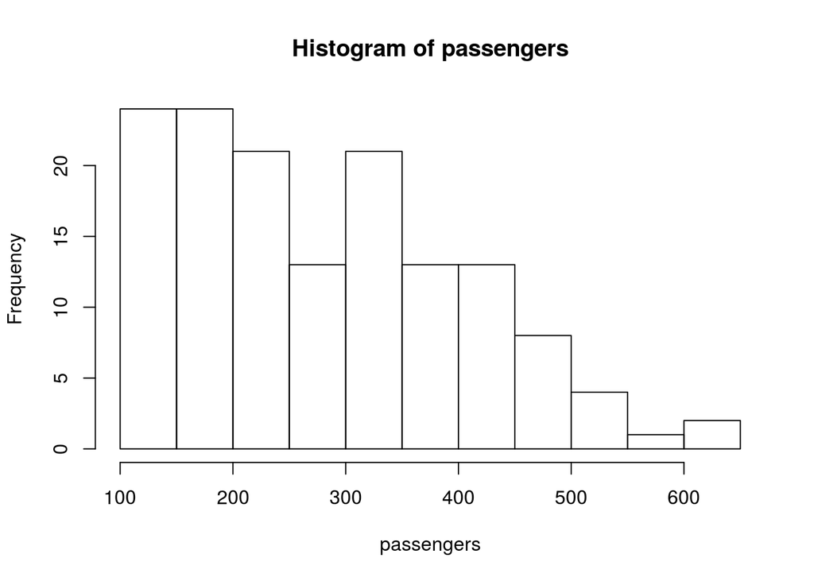

```r
hist(passengers)
```

What do you notice?

Draw a scatter plot of the number of passengers, in order, using the `plot` function. The main arguments to `plot` are `x` and `y`, vectors of x and y values. First draw the scatter plot with no further arguments, and then add the argument `type = "l"` which asks R to connect the points, which is probably more informative for data such as these.

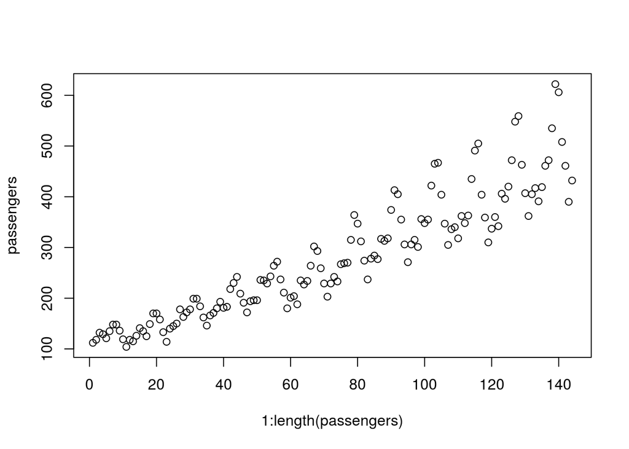

```r
plot(1:length(passengers), passengers)
```

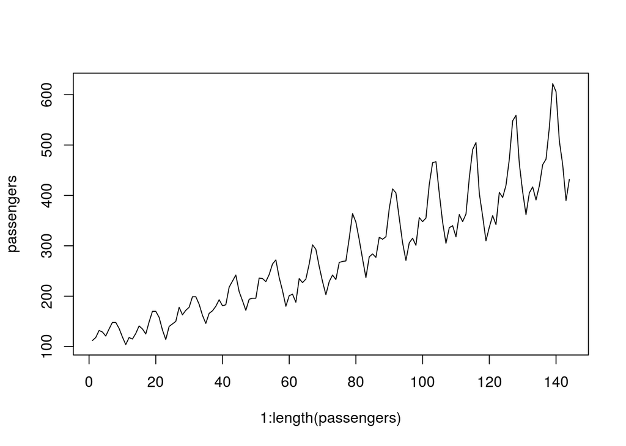

```r
plot(1:length(passengers), passengers, type = "l")
```

What do you notice from the scatter plots?